# Лабораторная работа № 5

Управление системными службами

Жукова С. В. НПИбд-01-24

Российский университет дружбы народов, Москва, Россия

3 октябоя 2025

## Докладчик

- Жукова София Викторовна
- студентка
- направления прикладной информатика
- Российский университет дружбы народов
- 1032240966@pfur.ru
- https://svzhukova.github.io/ru/

# Вводная часть

Управление системными службами

## Цель

Получить навыки управления системными службами операционной системы посредством systemd.

# Выполнение лабораторной работы

## Управление сервисами

Получим полномочия администратора и проверим статус службы Very Secure FTP Вывод команды показывает, что сервис в настоящее время отключён, так как служба Very Secure FTP не установлена.

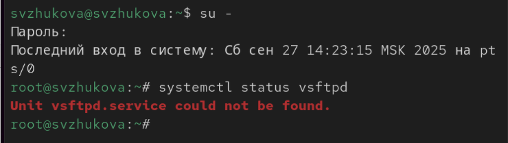

Статус службы Very Secure FTP

## Установим службу Very Secure FTP

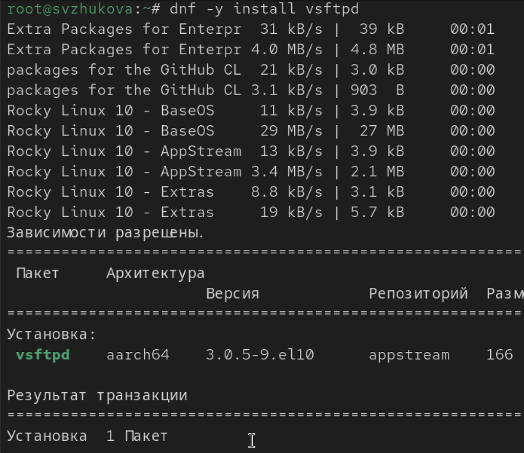

Установим

## Запустм и проверим службу Very Secure FTP

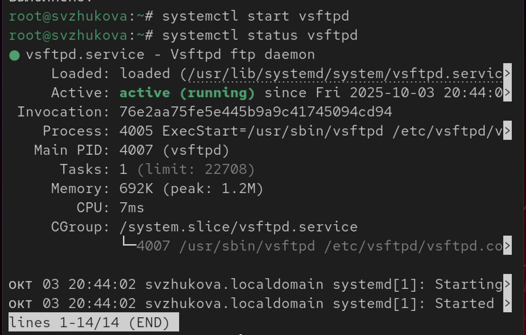

Вывод команды показывает, что служба в настоящее время работает, но не будет активирована при перезапуске операционной системы

## Добавим службу Very Secure FTP в автозапуск при загрузке операционной системы

Используя команду systemctl enable. Затем проверим статус службы. Удалим службу из автозапуска, используя команду systemctl disable, и снова проверим её статус.

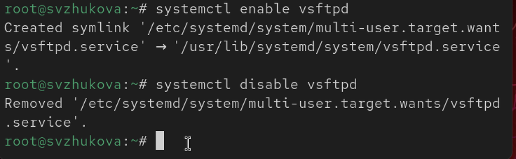

Проверка

## Выведем на экран символические ссылки, ответственные за запуск различных сервисов.

Отображается, что ссылка на vsftpd.service не существует.

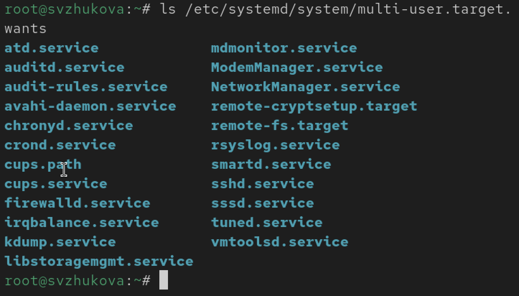

vsftpd.service ссылка не существует

## Снова добавим службу Very Secure FTP в автозапуск и выведем на экран символические ссылки, ответственные за запуск различных сервисов

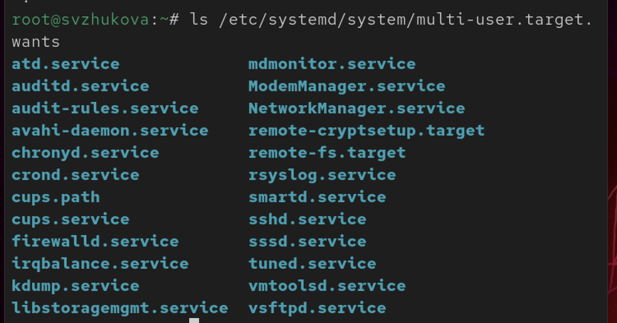

Служба появилась

## Снова проверим статус службы Very Secure FTP

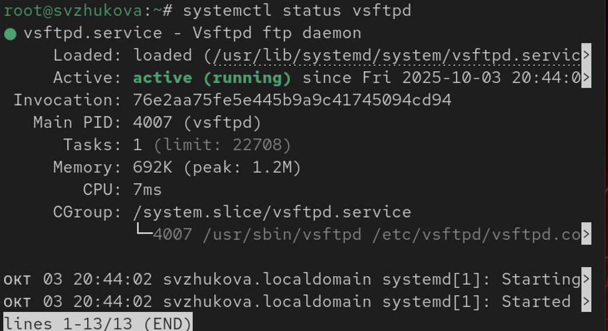

Для файла юнита состояние изменено с disabled на enabled.

## Выведем на экран список зависимостей юнита

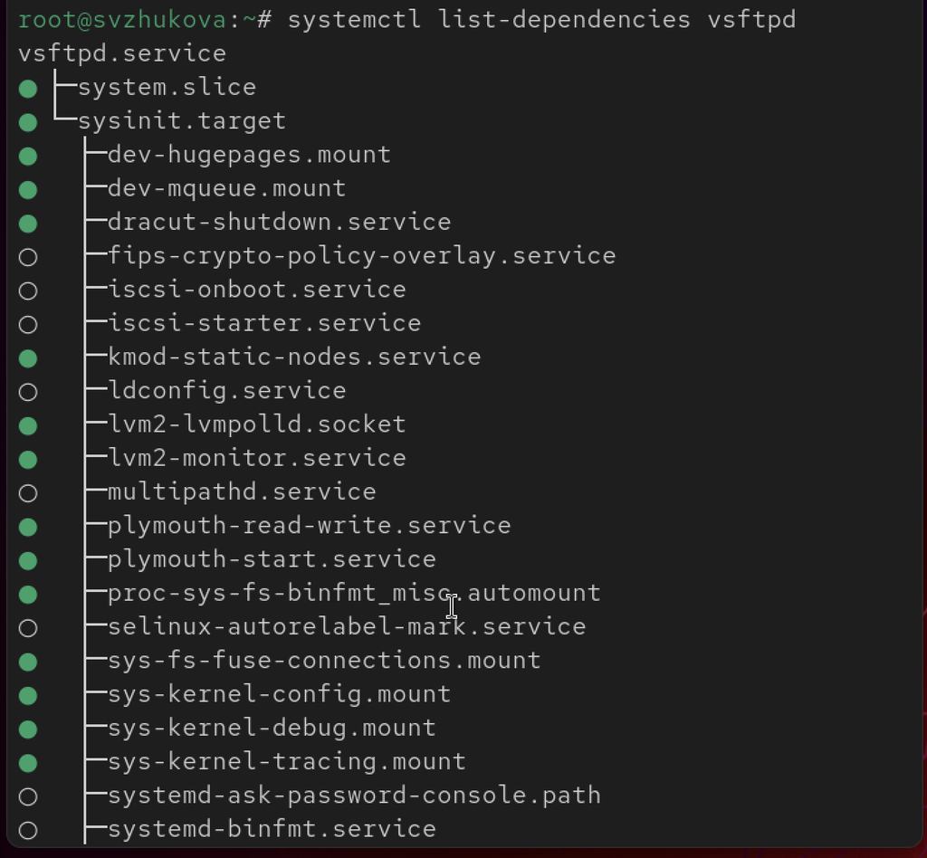

Список зависимостей юнита

## Выведем на экран список юнитов, которые зависят от данного юнита:

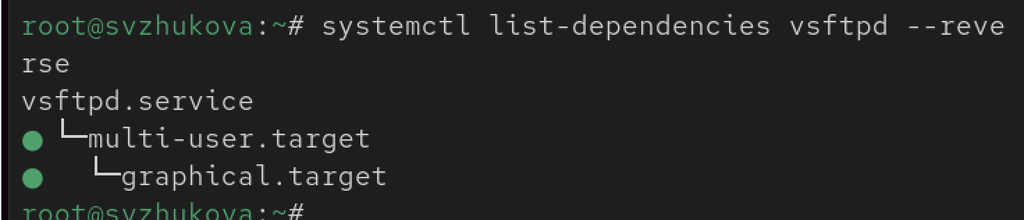

Список юнитов, которые зависят от данного юнита

# Конфликты юнитов

## Получим полномочия администратора. Установим iptables

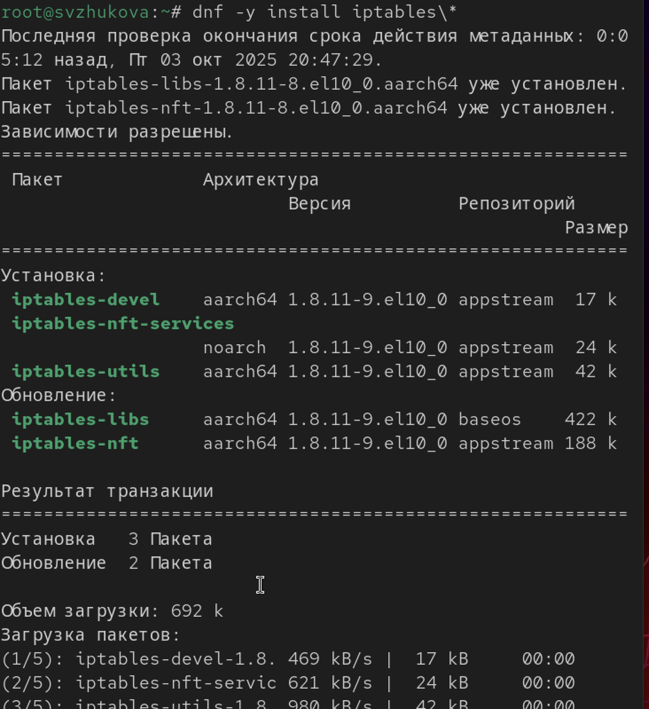

iptables

## Проверим статус firewalld и iptables

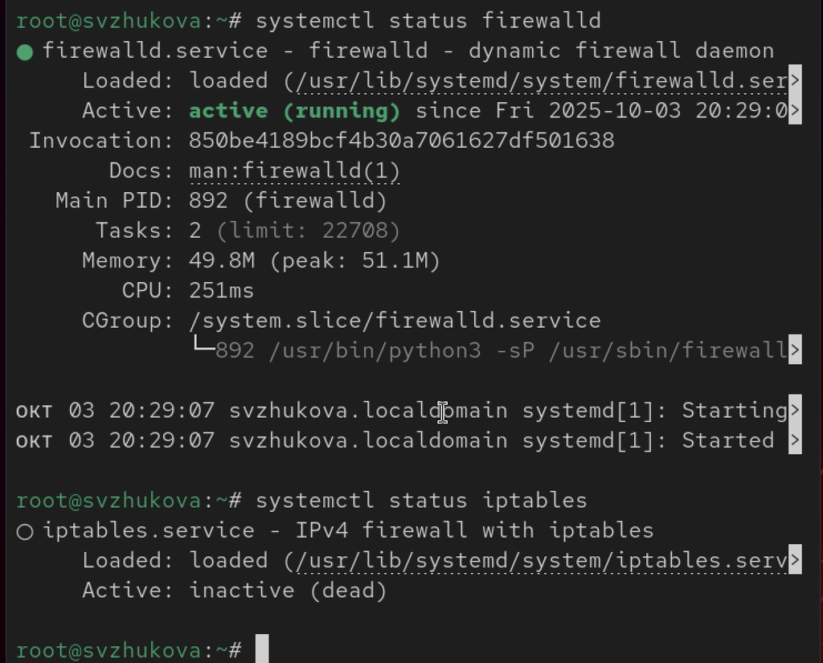

Проверим

## Попробуем запустить firewalld и iptables

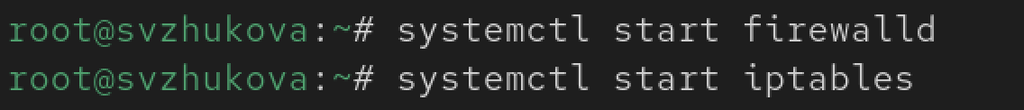

При запуске одной службы вторая дезактивируется или не запускается

## Введем

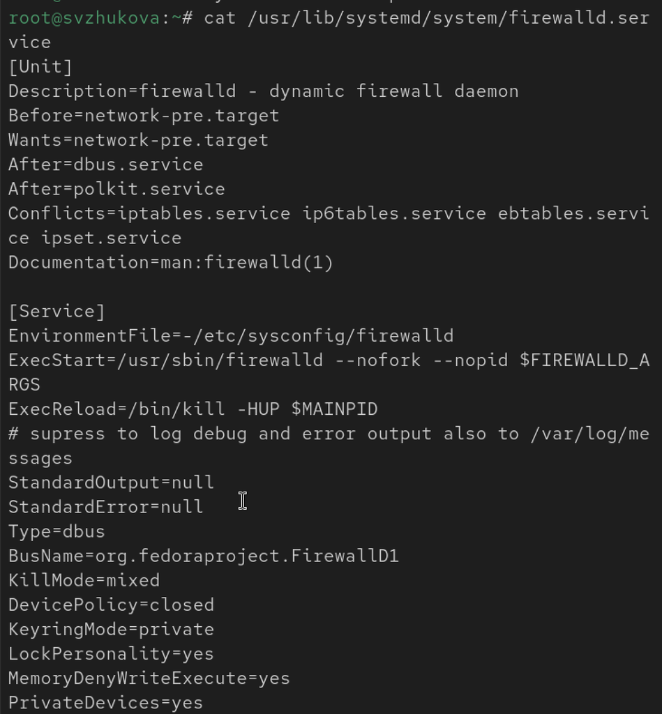

Настройки конфликтов для этого юнит

## Введем

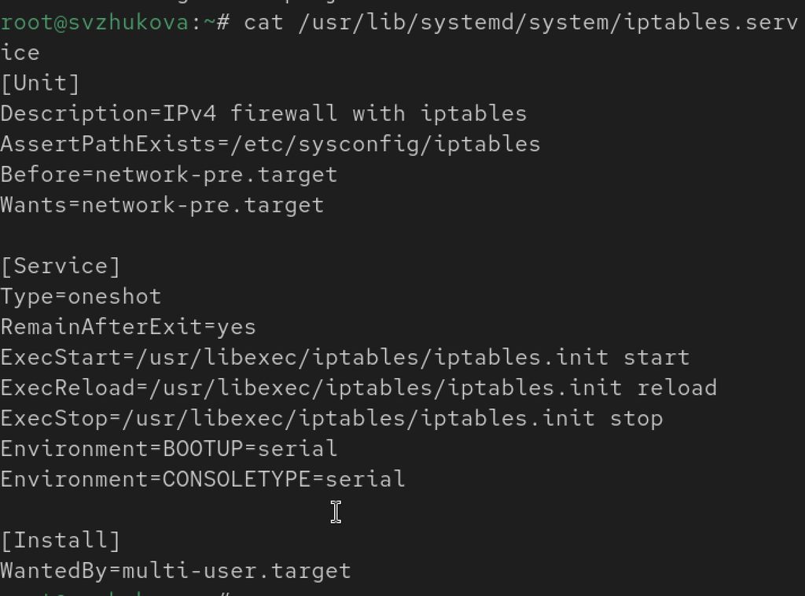

Настройки конфликтов для этого юнит

## Выгрузим службу iptables (на всякий случай, чтобы убедиться, что данная служба не загружена в систему)

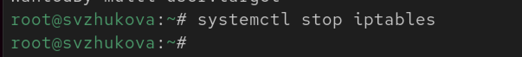

Выгрузим службу iptables

## Загрузим службу firewalld

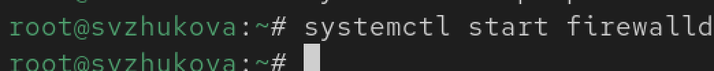

firewalld

## Заблокируем запуск iptables, введя.

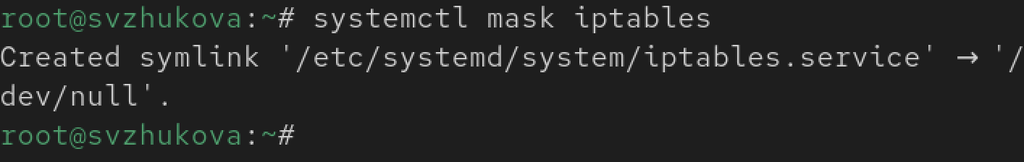

Заблокируем запуск iptables

## Попробуем запустить iptables

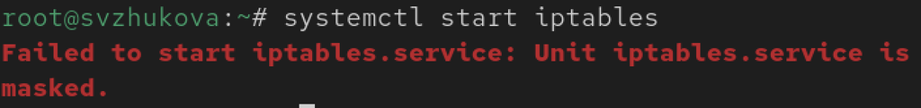

Появилось сообщение об ошибке, указывающее, что служба замаскирована и по этой причине не может быть запущена

## Попробуем добавить iptables в автозапуск

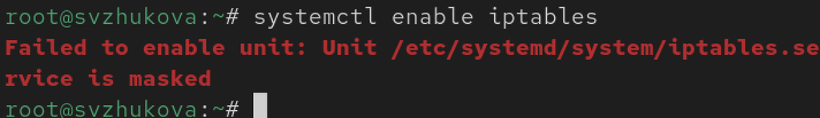

# Изолируемые цели

Получим полномочия администратора. Перейдем в каталог systemd и найдем список всех целей, которые можно изолировать

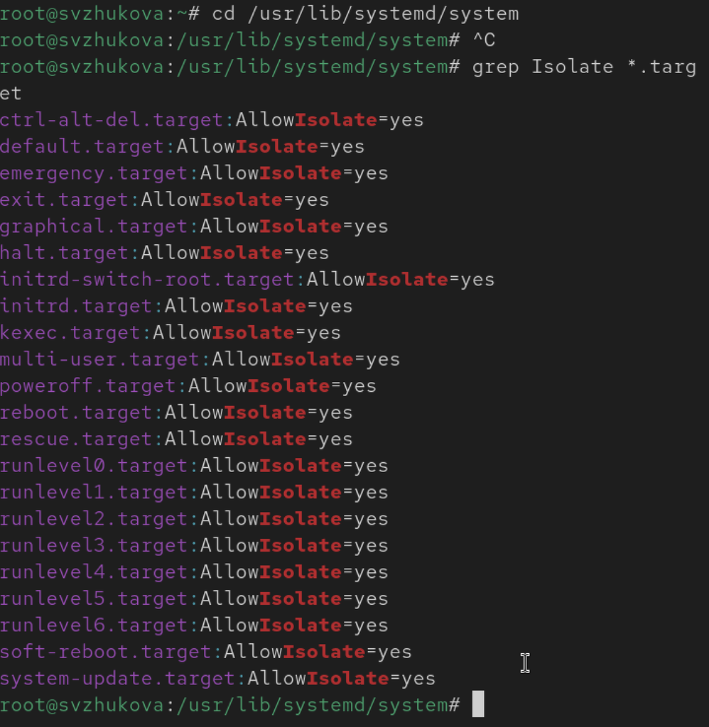

Список всех целей

# Переключим операционную систему в режим восстановления

Цель по умолчанию

Получим полномочия администратора. Выведем на экран цель, установленную по умолчанию

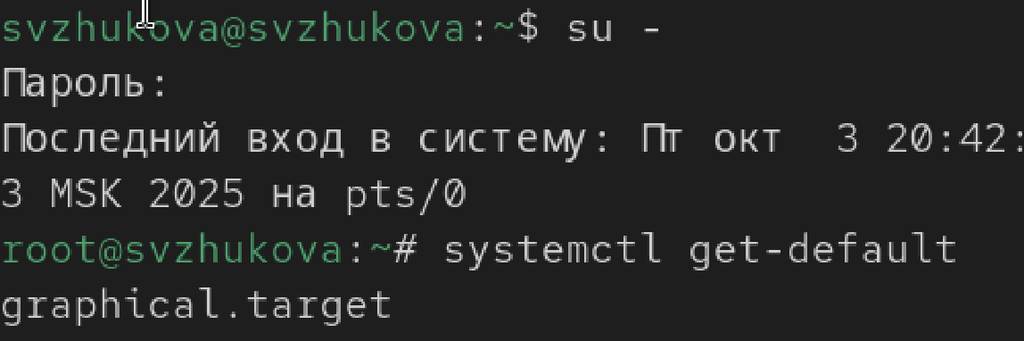

Выведем

## Для установки цели по умолчанию используем systemctl set-default multi-user.target

Для запуска по умолчанию текстового режима введем

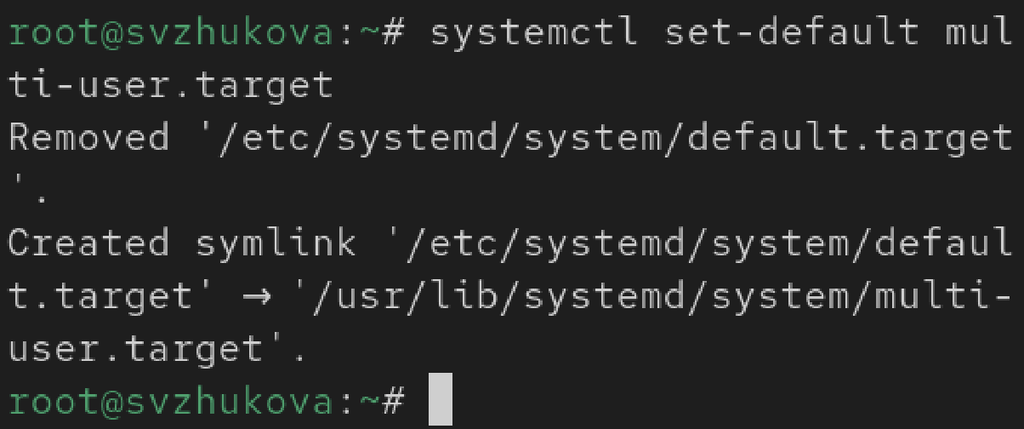

Запуск по умолчанию

## Перегрузим систему командой reboot. Убедимся, что система загрузилась в текстовом режиме. Получим полномочия администратора.

Для запуска по умолчанию графического режима введем systemctl set-default graphical.target Вновь перегрузим систему командой reboot. Убедимся, что система загрузилась в графическом режиме.

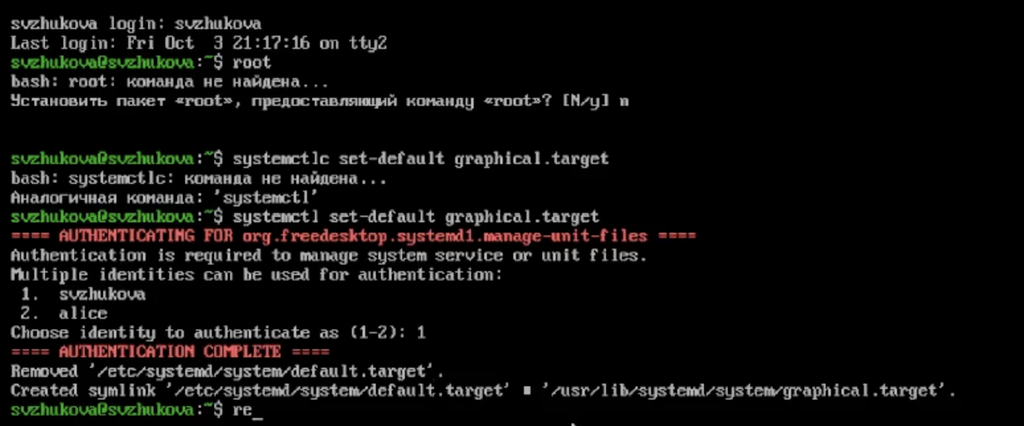

# Заключение

Мы приобрели навыки управления системными службами операционной системы посредством systemd.